# Revisiting the Wright-Fisher model as a Markov chain

We have played with a Wright-Fisher simulator in the exercises for the Monte Carlo session. Now, we will return to that, but will use it in tandem with Monte Carlo to ask questions about the nature of this Markov chain.

Big Note: Even though we are doing Monte Carlo with a Markov chain here, this is *not* Markov chain Monte Carlo.

As before, here is our Wright-Fisher simulation function:

```r
library(tidyverse)
#' simulate R reps of a Wright-Fisher model of size N haploids for T generations from an initial allele count of X0
#'
#' Default values for the simulatiions are given as shown.
#'
#' @param R number of replicate simulations to do
#' @param N number of haploids, each generation, in the population
#' @param T number of generations of sampling to simulate
#' @param X0 the initial number of A alleles.  Must be <= N
WF <- function(
  R = 1000,
  N = 100,
  T = 20,
  X0 = 30
) {
  stopifnot(X0 <= N)

  lapply(1:R, function(r) { # cycling over the different replicates
    # initialize a vector to store the results
    x <- rep(NA, T)

    # get X1
    x[1] <- rbinom(n = 1, size = N, prob = X0 / N)

    # cycle over the remaining generations (for loop is slow but makes
    # it easier to read what is going on)
    for (t in 2:T) {
      x[t] <- rbinom(n = 1, size = N, prob = x[t - 1] / N)
    }

    # return a tibble of results
    tibble(
      rep = r,
      t = 1:T,
      x = x
    )
  }) %>%
    bind_rows()   # at the end, bind them all into a single tibble
}
```

## Exercises

For the following exercises we will consider a small population with $N=10$.

1. Simulate $R = 1000$ replicates of this population, for $T = 500$ generations, from each of the possible starting points $X_0 = 0,\ldots,10$. Use Monte Carlo sampling to approximate the distribution of states at $T = 500$ for each of the starting values.

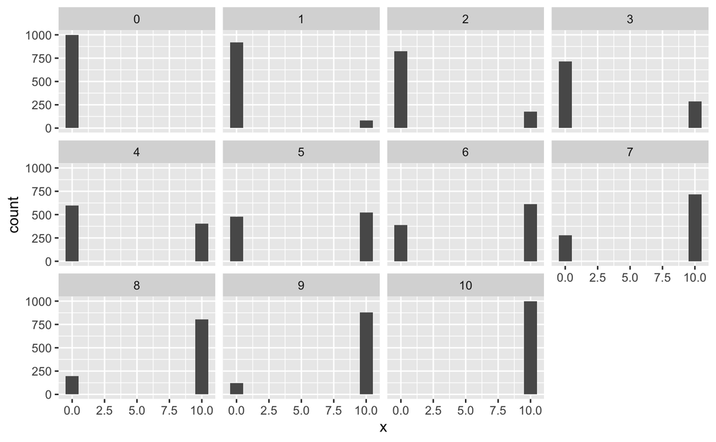

```r
mc_sample <- lapply(0:10, function(x0) {
  WF(
    R = 1000,
    N = 10,
    T = 500,
    X0 = x0
  ) %>%
    mutate(X0 = x0)
}
) %>%
  bind_rows()

mc_sample %>%
  filter(t == 500) %>%
  ggplot(aes(x = x)) +
  geom_histogram(binwidth = 1) +
  facet_wrap(~ X0)
```

2. Compare the results you obtained for the different starting values in exercise 1. Does it appear that there is a single, unique limiting distribution for this Markov chain? (i.e., so long as you run it long enough, the probability of being found in any state is unaffected by where you start).

No! Absolutely not!

3. Start at state $X_0=5$ in the chain, but run only a single replicate, $R=1$, for $T = 10,000$ generations. But this time, look at the distribution of states across the 10,000 time steps in that single run. Compare it to the distribution across the $R=1000$ replicates with $X_0 = 5$ of exercise 1. How do they compare?

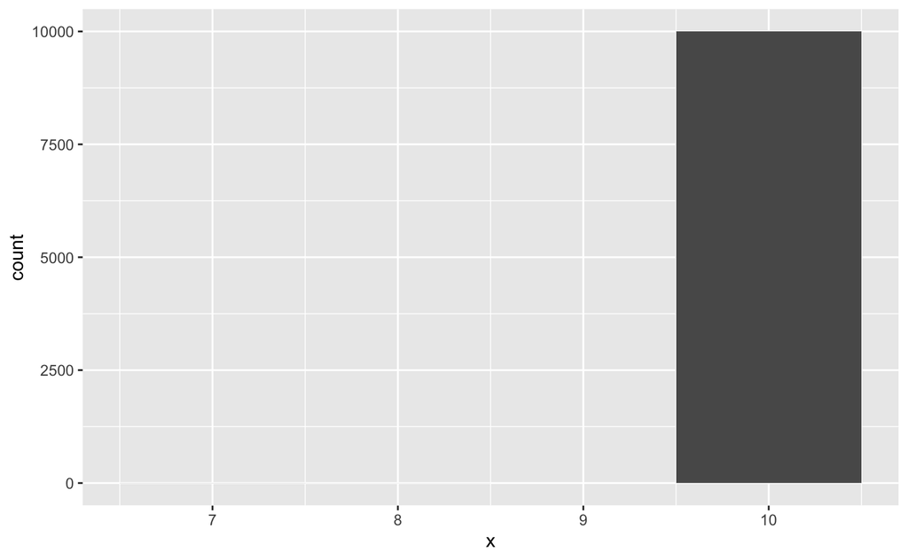

```r
sample2 <- WF(R = 1, N = 10, T = 10000, X0 = 5)
ggplot(sample2, aes(x = x)) +
  geom_histogram(binwidth = 1)
```

4. Is the Markov chain made by the Wright-Fisher population ergodic?

Absolutely not. The time average doesn’t look anything like what you get when you run the chain multiple times for a long time.

5. If not, which of the three conditions—recurrence, aperiodicity, or irreducibility—is violated?

The chain in not *irreducible*! If it gets to $x = 0$ or $x = N$ it just stays there. So none of the other states cannot be reached from $x = 0$ or $x = N$.